# Ciência de Dados

O objetivo desse notebook é aplicar a Linguagem R em Ciência de Dados na resolução de problemas de forma não supervisionada e supervisionada.

## Agrupando dados

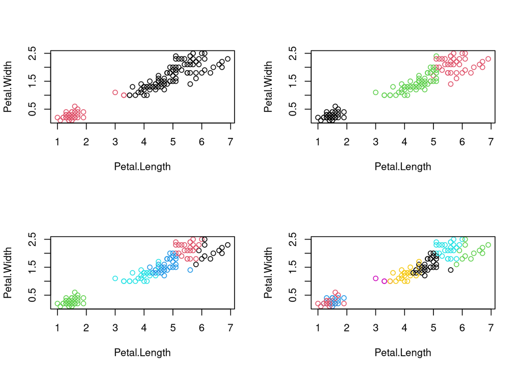

```r
par(mfrow=c(2,2))
plot = sapply(c(2,3,5,7), function(i) {
  centroides = kmeans(iris[,1:4], centers=i, iter.max=500, nstart=30, algorithm="MacQueen")
  plot(iris[,3:4], col=centroides$cluster)
})
```

## Comprimindo Imagens

Um experimento interessante é a tarefa de comprimir imagens utilizando o algoritmo de agrupamento KMeans. Para a compressão, o número de cores precisa ser reduzido. A redução é feita através do agrupamento das cores e seleção daquelas mais frequentes. Para isso precisamos carregar a blbioteca imager:

```r
if(!require('imager')) {
  install.packages('imager')
}
require('imager')
```

Algumas imagens são pré-carregadas pelo pacote como a imagem de barcos:

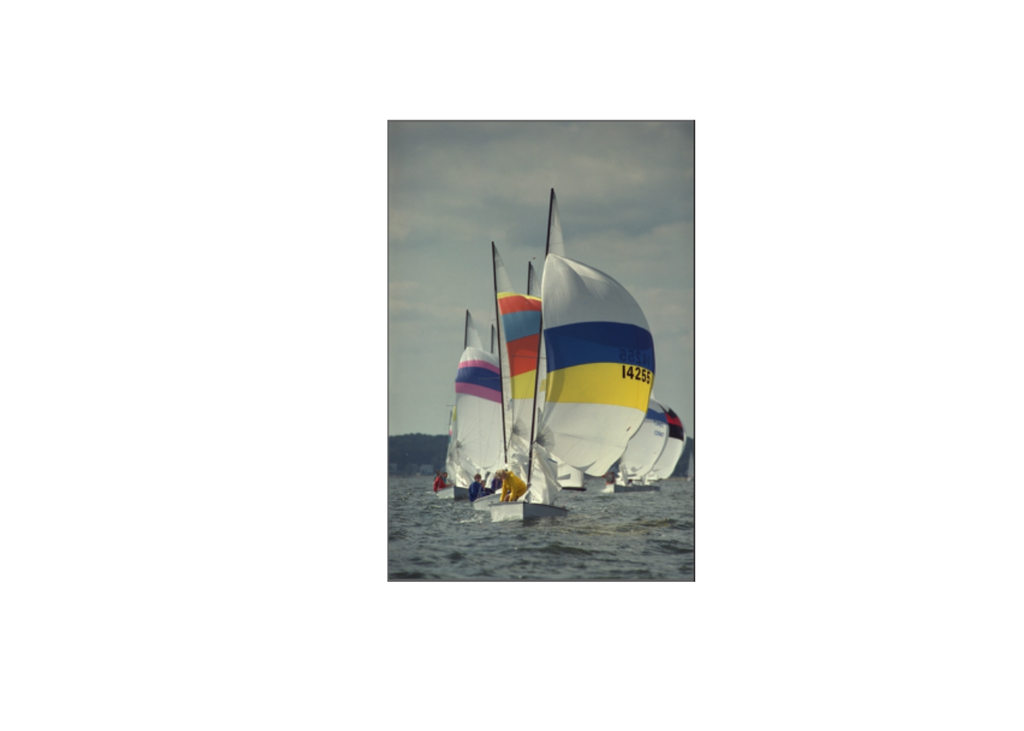

```r
plot(boats, axes=FALSE)
```

Vamos salvar a imagem original em um arquivo e imprimir seu tamanho em disco:

```r
save(boats, file='boats1.zip')
cat('Tamanho da imagem original:', file.info("boats1.zip")$size, 'bytes')
```

```
## Tamanho da imagem original: 1499617 bytes
```

Podemos extrair informações sobre o objeto da seguinte forma:

```r
boats
```

```
## Image. Width: 256 pix Height: 384 pix Depth: 1 Colour channels: 3
```

```r
dim(boats)
```

```
## [1] 256 384   1   3
```

Gerando o data.frame da imagem boats:

```r
image = as.data.frame(boats)
# cabecalho do data.frame
head(image)
```

|  | x | y | cc | value |
| --- | --- | --- | --- | --- |
| 1 | 1 | 1 | 1 | 0.3882353 |
| 2 | 2 | 1 | 1 | 0.3858633 |
| 3 | 3 | 1 | 1 | 0.3849406 |
| 4 | 4 | 1 | 1 | 0.3852481 |
| 5 | 5 | 1 | 1 | 0.3860388 |
| 6 | 6 | 1 | 1 | 0.3855557 |

Podemos deixar a imagem borrada:

[figure not shown]

```r
plot(isoblur(boats, 10), axes=FALSE)
```

Podemos deixar a imagem em escala de cinza:

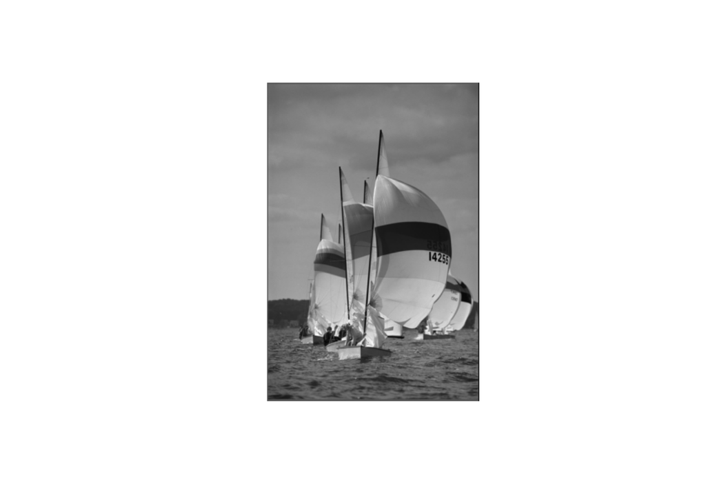

```r
plot(grayscale(boats), axes=FALSE)
```

Podemos remover a cor vermelha da imagem:

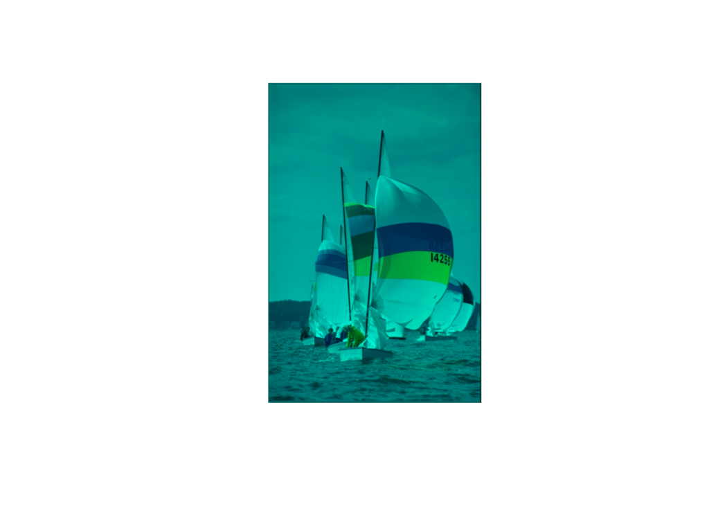

```r
test_image = image
test_image[test_image$cc == 1, 'value'] = 0
test_image = as.cimg(test_image)
plot(test_image, axes=FALSE)
```

Podemos separar as cores RGB da imagem da seguinte forma:

```r
red = image[image$cc == 1, 'value']
blue = image[image$cc == 2, 'value']
green = image[image$cc == 3, 'value']
```

Reconstruindo a base de dados em um data.frame:

```r
data = data.frame(red, blue, green)
```

Aplicando o KMeans com 10 centroides e 500 iterações máximas:

```r
centroides = kmeans(data, centers=10, iter.max=500, nstart=30, algorithm="MacQueen")
summary(centroides)
```

```
##              Length Class  Mode
## cluster      98304  -none- numeric
## centers         30  -none- numeric
## totss            1  -none- numeric
## withinss        10  -none- numeric
## tot.withinss     1  -none- numeric
## betweenss        1  -none- numeric
## size            10  -none- numeric
## iter             1  -none- numeric
## ifault           0  -none- NULL
```

Adicionando os centroides encontrados em data:

```r
data[,"cluster"] = centroides$cluster
head(data)
```

|  | red | blue | green | cluster |
| --- | --- | --- | --- | --- |
| 1 | 0.3882353 | 0.3882353 | 0.3882353 | 6 |
| 2 | 0.3858633 | 0.3858633 | 0.3858633 | 6 |
| 3 | 0.3849406 | 0.3849406 | 0.3849406 | 6 |
| 4 | 0.3852481 | 0.3852481 | 0.3852481 | 6 |
| 5 | 0.3860388 | 0.3860388 | 0.3860388 | 6 |
| 6 | 0.3855557 | 0.3855557 | 0.3855557 | 6 |

O próximo passo é reconstruir a imagem utilizando as cores identificadas como centroides. A imagem será reconstrída com as 10 cores principais:

```r
new_data = do.call('rbind',
  lapply(1:nrow(data), function(i) {
    centroides$centers[data[i,4],]
  })
)
```

Plotando a nova imagem:

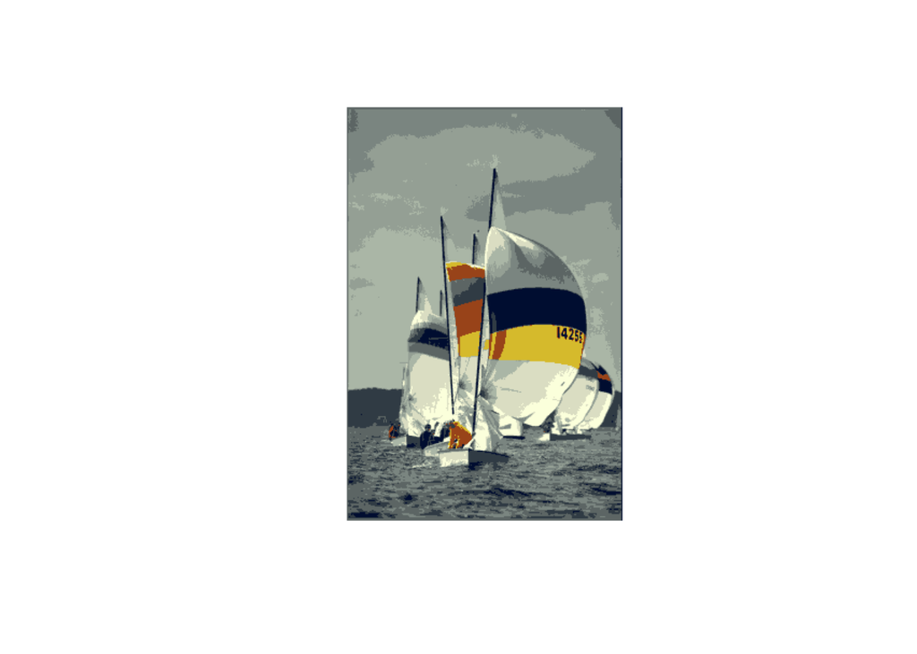

```r
new_image = image
new_image$value = c(new_data[,1], new_data[,2], new_data[,3])
new_image = as.cimg(new_image)
plot(new_image, axes=FALSE)
```

Vamos salvar a nova imagem em um arquivo e imprimir o seu tamanho comprimido em disco:

```r
save(new_image, file='boats2.zip')
cat('Tamanho da imagem comprimida:', file.info("boats2.zip")$size, 'bytes')
```

```
## Tamanho da imagem comprimida: 55843 bytes
```

Antes de continuar com o experimento, vamos construir a função imageGenerator que recebe uma imagem e o número de centroides e retorna uma nova imagem comprimida:

```r
imageGenerator <- function(image, centers) {

  image = as.data.frame(image)
  red = image[image$cc == 1, 'value']
  blue = image[image$cc == 2, 'value']
  green = image[image$cc == 3, 'value']
  data = data.frame(red, blue, green)

  centroides = kmeans(data, centers, iter.max=500, nstart=30, algorithm="MacQueen")
  data[,"cluster"] = centroides$cluster

  new_data = do.call('rbind',
    lapply(1:nrow(data), function(i) {
      centroides$centers[data[i,4],]
    })
  )

  new_image = image
  new_image$value = c(new_data[,1], new_data[,2], new_data[,3])
  as.cimg(new_image)
}
```

Usando a função imageGenerator podemos gerar diferentes imagens com diferentes números de cores. Segue o resultado do experimento para 10, 32, 64 e 128 cores:

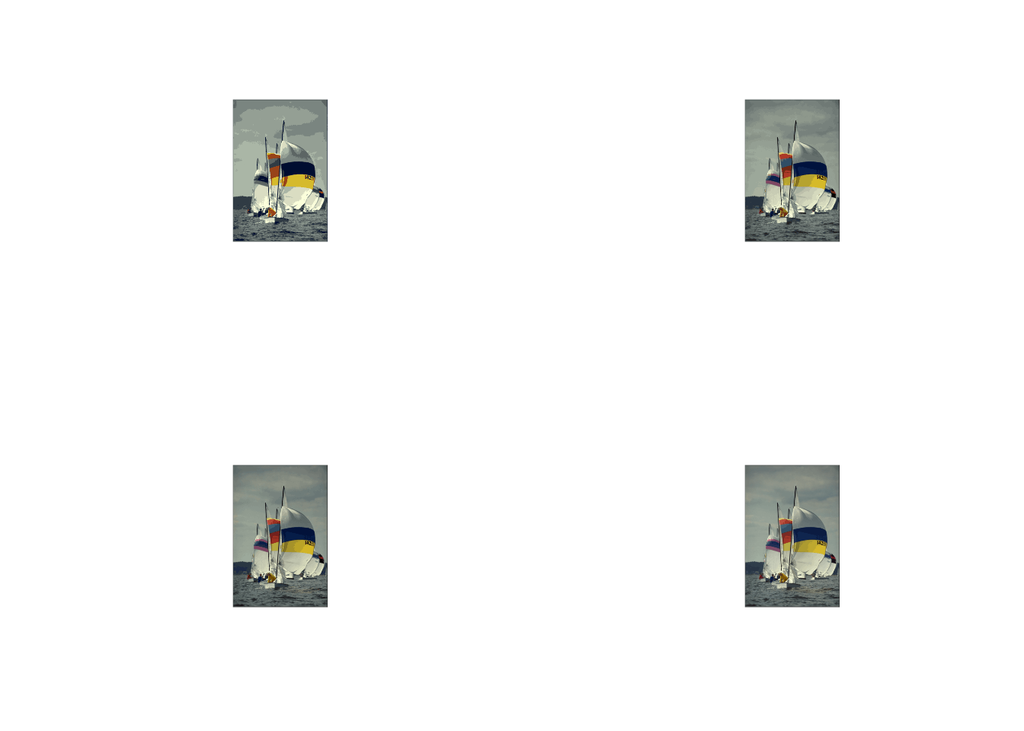

```r
par(mfrow=c(2,2))
plot = sapply(c(10, 32, 64, 128), function(i) {
  plot(imageGenerator(boats, i), axes=FALSE)
})
```

## Classificando dígitos

Um experimento interessante é a tarefa de classificar dígitos utilizando o algoritmo de Redes Neurais Artificiais. Para isso precisamos relizar os experimentos em duas fases: (1) treinar a rede para reconhecer os dígitos e (2) utilizá-la para classificar novos dígitos. Para isso precisamos carregar as blbiotecas tensorflow e keras:

```r
if(!require('tensorflow')) {
  install.packages('tensorflow')
}
require('tensorflow')
```

```r
if(!require('keras')) {
  install.packages('keras')
}
require('keras')
```

A base de dados de dígitos se chama MNIST e pode ser carregada com a função dataset_mnist. Ela contém 60000 amostras dos dígitos 0 até 9. Cada dígito é uma imagem de 28 x 28 pixels.

```r
mnist = dataset_mnist()
```

A função show_digit recebe um dígito na forma de uma matriz 28 x 28 e imprime o dígito na forma de imagem.

```r
show_digit <- function(numero) {
  image(numero[1:28,28:1])
}
```

Podemos utilizar a função show_digit para plotar uma amostra de todos os dígitos presentes na base de dados:

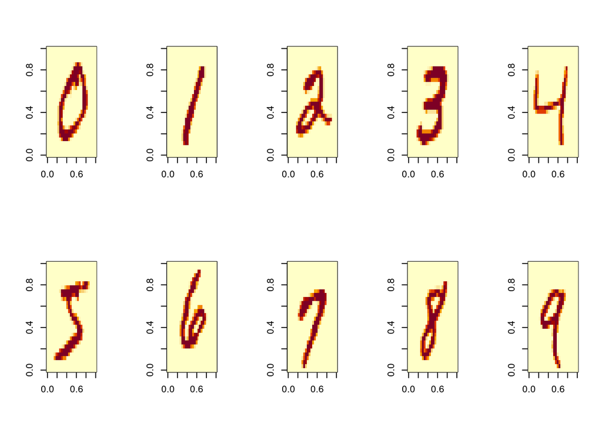

```r
par(mfrow=c(2,5))
plot = lapply(0:9, function(i) {
  aux = mnist$train$x[mnist$train$y == i,,][1,,]
  show_digit(t(aux))
})
```

Normalizando os dados de treinamento e teste:

```r
mnist$train$x <- mnist$train$x/255
mnist$test$x <- mnist$test$x/255
```

```r
modelo = keras_model_sequential() %>%
  layer_flatten(input_shape = c(28, 28)) %>%
  layer_dense(units = 128, activation = "relu") %>%
  layer_dense(10, activation = "softmax")
```

Informações sobre a Rede Neural Artificial:

```r
summary(modelo)
```

```
## Model: "sequential"
## ________________________________________________________________________________
## Layer (type)                        Output Shape                    Param #
## ================================================================================
## flatten (Flatten)                   (None, 784)                     0
## ________________________________________________________________________________
## dense (Dense)                       (None, 128)                     100480
## ________________________________________________________________________________
## dense_1 (Dense)                     (None, 10)                      1290
## ================================================================================
## Total params: 101,770
## Trainable params: 101,770
## Non-trainable params: 0
## ________________________________________________________________________________
```

Ainda precisamos definir o algoritmo de treinamento, a função de avaliação e a medida de desempenho que vamos utilizar. Podemos fazer isso com a função compile:

```r
modelo %>%
  compile(
    loss = "sparse_categorical_crossentropy",
    optimizer = "adam",
    metrics = "accuracy"
  )
```

Agora podemos treinar a rede:

```r
historico = modelo %>%
  fit(
    x = mnist$train$x, y = mnist$train$y,
    epochs = 10,
    validation_split = 0.3,
    verbose = 2
  )
```

É interessante medir o erro e o desempenho da rede ao longo das épocas no conjunto de treinamento e validação.

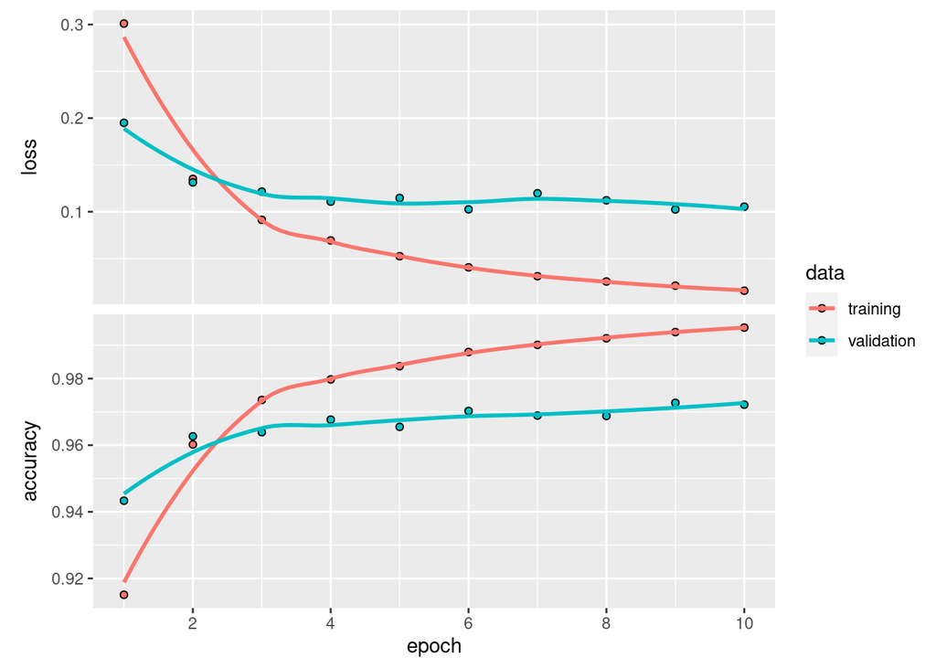

```r
plot(historico)
```

Agora que sabemos que a rede aprendeu a reconhecer dígitos, podemos verificar seu desempenho no conjunto de teste. Para isso precisamos aplicar essas amostras nunca antes vistas na entrada da rede e obter os valores de saída:

```r
predicao <- predict(modelo, mnist$test$x)
head(predicao)
```

```
##              [,1]         [,2]         [,3]         [,4]         [,5]
## [1,] 2.059010e-09 1.532758e-09 7.418290e-07 1.463930e-04 1.089915e-12
## [2,] 2.268435e-14 3.213584e-07 9.999995e-01 4.036881e-09 4.027988e-17
## [3,] 4.462315e-07 9.995098e-01 9.156477e-05 1.344052e-06 1.954959e-05
## [4,] 9.999300e-01 3.782149e-11 9.947705e-06 1.005156e-07 6.509965e-10
## [5,] 2.085142e-09 1.463931e-12 1.474249e-11 5.692581e-11 9.999859e-01
## [6,] 3.507708e-09 9.998329e-01 1.695193e-07 6.236768e-08 4.264336e-06
##              [,6]         [,7]         [,8]         [,9]        [,10]
## [1,] 5.234786e-11 2.611173e-12 9.998522e-01 4.852774e-08 6.143524e-07
## [2,] 4.771833e-11 2.737375e-11 2.055657e-16 7.080438e-08 1.235904e-16
## [3,] 4.085769e-07 1.029063e-06 2.108728e-04 1.648779e-04 1.163322e-07
## [4,] 2.021323e-07 4.857753e-05 1.119175e-05 8.207794e-11 8.429284e-09
## [5,] 1.442924e-12 8.248796e-10 4.499346e-08 1.525127e-09 1.405080e-05
## [6,] 1.468367e-10 1.301944e-09 1.591539e-04 3.442668e-06 5.784182e-09
```

Cada neurônio de saída da rede irá retornar um valor. Aquele neurônio com maior valor deve indicar a classe com maior proababilidade:

```r
predicao = apply(predicao, 1, which.max)
predicao[1:6]
```

```
## [1] 8 3 2 1 5 2
```

Calculando o desempenho da rede no conjunto de teste:

```r
matriz = table(mnist$test$y, predicao)
acuracia = sum(diag(matriz))/sum(matriz)
cat('A acurácia do modelo no conjunto de teste eh:', acuracia)
```

```
## A acurácia do modelo no conjunto de teste eh: 0.9762
```